# Assignment5

## 1.5 Box plots and outliers

## 1.5 Q1

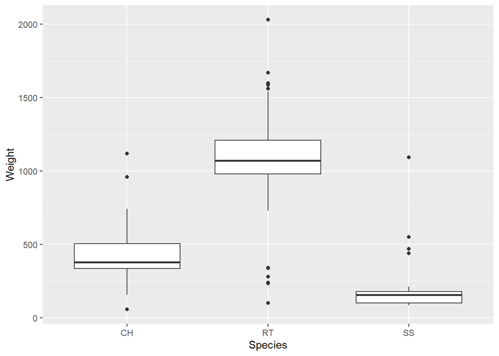

```r
ggplot(data=Hawks,aes(x=Species,y=Weight))+geom_boxplot()
```

## 1.5 Q2 quantile and boxplots

```r
quantiles <- Hawks %>% group_by(Species) %>% summarise(across("Weight",list(quantile025=~quantile(.,probs=0.25,na.rm=TRUE),quantile050=~ quantile(.,probs=0.5,na.rm=TRUE),quantile075=~quantile(.,probs=0.75,na.rm=TRUE))))
quantiles
```

```
## # A tibble: 3 × 4
##   Species Weight_quantile025 Weight_quantile050 Weight_quantile075
##   <fct>                <dbl>              <dbl>              <dbl>
## 1 CH                     335               378.               505
## 2 RT                     980              1070               1210
## 3 SS                     100               155                178.
```

```r
# These numbers are correspond to the box (interquartile range)
```

## 1.5 Q3 Outliers

```r
num_outliers <- function(x){
  #remove any nans
  x <- x[!is.na(x)]
  # compute q25 and q75
  q25 <- quantile(x,0.25,na.rm=TRUE)
  q75 <- quantile(x,0.75,na.rm=TRUE)
  # create IQR
  IQR <- q75 - q25
  n <- 0
  for(num in x){
    if(num < q25-1.5*IQR | num > q75+1.5*IQR){
      n <- n + 1
    }
  }
  return (n)
}
num_outliers(c(0,40,60,185))
```

```
## [1] 1
```

## 1.5 Q4 Outliers by group

```r
Hawks %>% group_by(Species) %>% summarise(across("Weight",list(num_outliers_weight=~num_outliers(.))))
```

```
## # A tibble: 3 × 2
##   Species Weight_num_outliers_weight
##   <fct>                        <dbl>
## 1 CH                               3
## 2 RT                              13
## 3 SS                               4
```

## 1.6 Covariance and correlation under linear transformations

## 1.6 Q1 Compute the covariance and correlation

```r
cov(Hawks[["Weight"]],Hawks[["Wing"]],use="complete.obs")
```

```
## [1] 41174.39
```

```r
cor(Hawks[["Weight"]],Hawks[["Wing"]],use="complete.obs")
```

```
## [1] 0.9348575
```

## 1.6 Q2

$Cov(\tilde{X},\tilde{Y})=a \times c \times Cov(X,Y)=a \times c \times S$

```r
# Verify Cov
cov(Hawks[["Weight"]]*2.4+7.1,Hawks[["Wing"]]*(-1)+3,use="complete.obs")
```

```
## [1] -98818.54
```

```r
cov(Hawks[["Weight"]],Hawks[["Wing"]],use="complete.obs")*2.4*(-1)
```

```
## [1] -98818.54
```

```r
# Verify Cor
cor(Hawks[["Weight"]]*2.4+7.1,Hawks[["Wing"]]*(-1)+3,use="complete.obs")
```

```
## [1] -0.9348575
```

```r
cor(Hawks[["Weight"]],Hawks[["Wing"]],use="complete.obs")
```

```
## [1] 0.9348575
```

# 2. Random variables and discrete random variables

## 2.1 Q1 Expectation and variance

$E[(X-\overline{X})\cdot(Y-\overline{Y})]=E(XY)-E(X\overline{Y})-E(\overline{X}Y)+E(\overline{X}\overline{Y})=E(XY)-E(XY)-E(XY)+E(XY)=0$

## 2.2 Distribution

## 2.2 Q1

### 1. What is the probability mass function px for X?

$p_X(x)=P(X=x)= \begin{cases} \alpha,X=3 \\ \beta,X=10 \\ 1-\alpha-\beta,X=0 \\ 0, otherwise \end{cases}$

### 2. What is the expectation of 𝑋?

$E(X)=\sum_{x} x \cdot p_X(x)=3 \cdot \alpha+10 \cdot \beta + 0 \times (1-\alpha-\beta)=3\alpha+10\beta$

### 3. What is the variance of X?

$Var(X)=E[(X-E(X))^2]=\sum_{x}(X-E(X))^2 \cdot p_X(x)=(3-3\alpha-10\beta)^2 \times \alpha + (10-3\alpha-10\beta)^2 \times \beta + (0-3\alpha-10\beta)^2 \times (1-\alpha-\beta) = 9\alpha+100\beta-9\alpha^2-100\beta^2-60\alpha\beta$

### 4. What is the standard deviation of X?

$\sigma{(X)}=\sqrt{Var(X)}=\sqrt{9\alpha+100\beta-9\alpha^2-100\beta^2-60\alpha\beta}$

## 2.2 Q2 Distribution and distribution function

### 1.

$P(S)=\alpha \times 1_{(3)}(x) + \beta \times 1_{(10)}(x) + (1-\alpha-\beta) \times \ 1_{(0)}(x)$

### 2. Write down the distribution function 𝐹 of 𝑋

$F_X(x)= \begin{cases} 0,& \quad if \quad x<0 \\ 1-\alpha-\beta,& \quad if \quad 0\leq x < 3 \\ 1-\beta,& \quad if \quad 3 \leq x <10 \\ 1,& \quad if \quad x \geq 10 \end{cases}$

## 2.2 Q3 Variance and Covariance

$Var(Y)=n \cdot Var(X)=n \cdot (9\alpha+100\beta-9\alpha^2-60\alpha\beta-100\beta^2)$

## 2.2 Q4

```r
# create function to generate a sample then return a vector
Gen_X_numbers <- function(n){
  numbers <- c()
  nums <- sample(seq(0,1,by=0.01),n)
  for(num in nums){
    if(num < 0.5){
      numbers <- c(numbers,0)
    }else if(num < 0.7){
      numbers <- c(numbers,3)
    }else{
      numbers <- c(numbers,10)
    }
  }
  return (numbers)
}
Gen_X_numbers(4)
```

```
## [1] 10  0 10  0
```

```r
# create function to generate a sample of Y
Gen_Y_samples <- function(m,n){
  iters <- seq(1,m)
  Y <- map_dbl(iters,~sum(Gen_X_numbers(n)))
  result <- data.frame(index=iters,Y=Y)
  return (result)
}
Gen_Y_samples(5,2)
```

```
##   index  Y
## 1     1 20
## 2     2  3
## 3     3  0
## 4     4 13
## 5     5 10
```

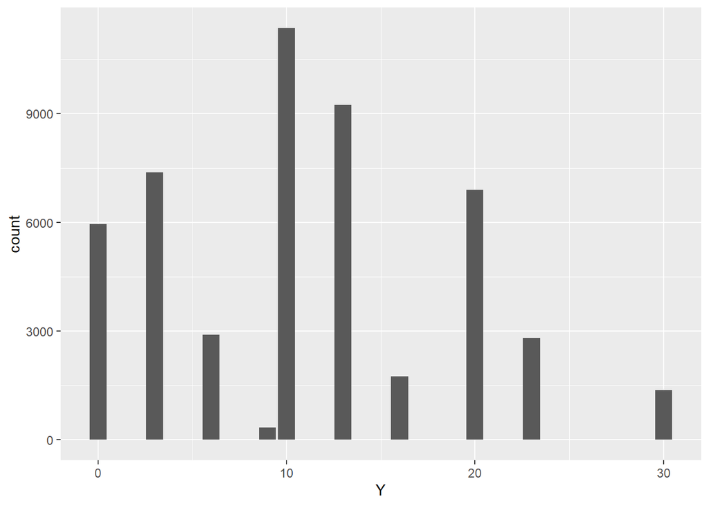

```r
# let n=3, m=50000
Gen_Y_samples(50000,3) %>% ggplot(aes(x=Y)) + geom_bar() + ylab("count")
```

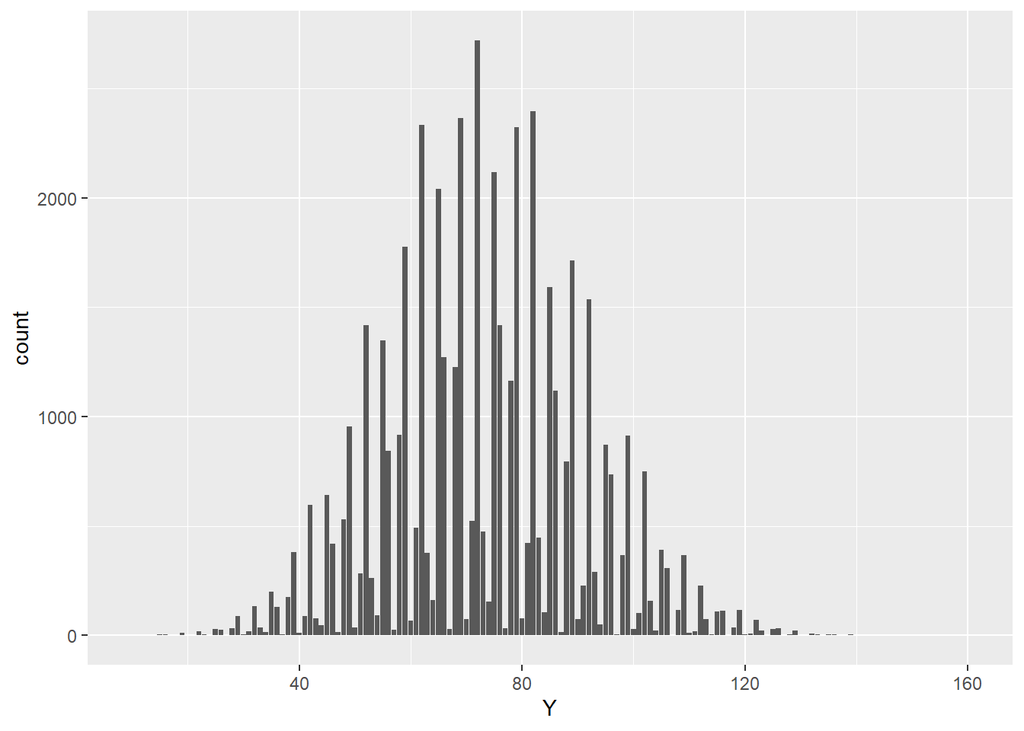

```r
# increase the values of n to 20
Gen_Y_samples(50000,20) %>% ggplot(aes(x=Y)) + geom_bar() + ylab("count")
```

```r
# increase n to 1000
# It is too large
#Gen_Y_samples(50000,1000) %>% ggplot(aes(x=Y)) + geom_bar() + ylab("count")
```

# 3. Continuous random variables and limit laws

## 3.1 Simulating data with the uniform distribution

## 3.1 Q1

$\mathbb{P}(U \in [a,b])=\int_a^b1dx=b-a$

## 3.1 Q2

```r
set.seed(0)
n <- 1000
sample_X <- data.frame(U=runif(n)) %>% mutate(X=case_when(
  (0<=U)&(U<0.25)~3,
  (0.25<=U)&(U<0.5)~10,
  (0.5<=U)&(U<=1)~0
)) %>% pull(X)

X3 <- 0
X10 <- 0
X0 <- 0
for(n in sample_X){
  if (n == 3){
    X3 <- X3+1
  }else if(n == 10){
    X10 <- X10+1
  }else{
    X0 <- X0+1
  }
}
X3/1000
```

```
## [1] 0.244
```

```r
X10/1000
```

```
## [1] 0.275
```

```r
X0/1000
```

```
## [1] 0.481
```

## 3.1 Q3

```r
sample_X_0310 <- function(alpha,beta,n){
  probability <- c(alpha,beta,1-alpha-beta)
  return (sample(c(3,10,0),n,replace=TRUE,prob=probability))
}
sample_X_0310(0.25,0.25,10)
```

```
##  [1]  0 10 10  0  3  0  0 10 10  3
```

## 3.1 Q4

```r
X <- sample_X_0310(1/2,1/10,10000)
X_mean <- mean(X,na.rm=TRUE)
X_mean
```

```
## [1] 2.5308
```

```r
X_E <- 3*(1/2) + 10*(1/10) + 0*(1-1/2-1/10)
X_E
```

```
## [1] 2.5
```

```r
# They are closed, if the sample is larger, then they will be closer
```

## 3.1 Q5

```r
X_Var <- var(X,na.rm=TRUE)
X_Var
```

```
## [1] 8.412293
```

```r
3*3*(1/2) + 10*10*(1/10) + 0*0*(1-1/2-1/10) - (3*(1/2) + 10*(1/10) + 0*(1-1/2-1/10))^2
```

```
## [1] 8.25
```

## 3.1 Q6

```r
# 1. "beta" column
beta <- seq(0,9/10,by=0.01)

# 2. "sample_X" column
# 3. "samplemean" column
sample_list <- list()
sample_mean <- c()
for(value in beta){
  sample_X <- sample_X_0310(1/10,value,100)
  sample_mean <- c(sample_mean,mean(sample_X,na.rm=TRUE))
  sample_list <- append(sample_list, list(paste(sample_X, collapse=", ")))
}
result <- data.frame(beta=beta, sample_X=unlist(sample_list), samplemean=sample_mean)

result <- result %>% mutate(Expectation=3*(1/10)+10*beta)
```

## 3.1 Q7

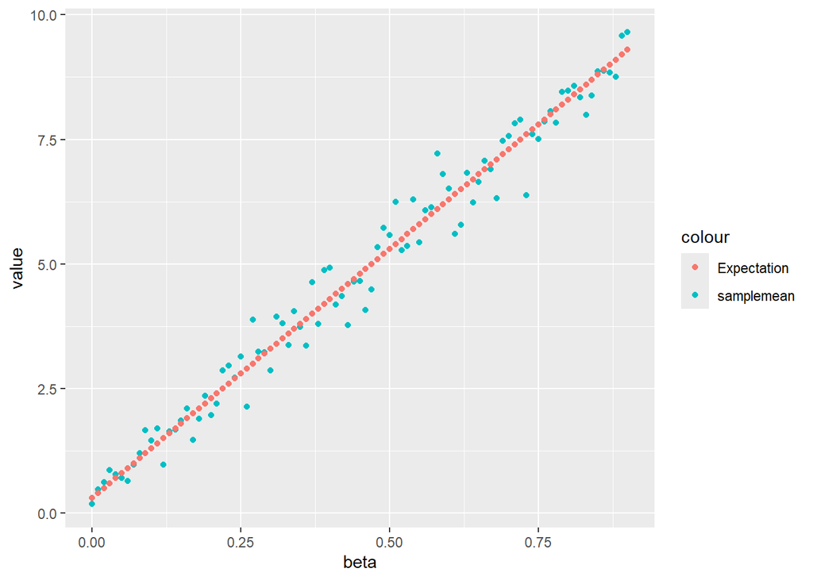

```r
result %>% ggplot(aes(x=beta)) + geom_point(aes(y=samplemean, color="samplemean")) + geom_point(aes(y=Expectation,color="Expectation")) + xlab("beta") + ylab("value")
```

## 3.2 Exponential distribution

## 3.2 Q1

$\int_{-\infty}^{\infty}p(x)dx=1$ $\int_{-\infty}^{\infty}p(x)dx=\int_{-\infty}^{\infty}0dx+\int_{-\infty}^{\infty}\lambda e^{-\lambda x} dx$ $Then, \quad \int_{-\infty}^{\infty}\lambda e^{-\lambda x}dx=[-e^{-\lambda x}]_0^{\infty}=(0-(-1))=1$

## 3.2 Q2

```r
my_cdf_exp <- function(x,lambda){
  Fx <- 1-exp(-lambda*x)
  if (Fx < 0){
    Fx <- 0
  }
  return (Fx)
}
lambda <- 1/2
map_dbl(.x=seq(-1,4), .f=~my_cdf_exp(x=.x,lambda=lambda))
```

```
## [1] 0.0000000 0.0000000 0.3934693 0.6321206 0.7768698 0.8646647
```

```r
test_inputs <- seq(-1,10,0.1)
my_cdf_output <- map_dbl(.x=test_inputs,.f=~my_cdf_exp(x=.x,lambda=lambda))
inbuilt_cdf_output <- map_dbl(.x=test_inputs,.f=~pexp(q=.x,rate=lambda))
all.equal(my_cdf_output,inbuilt_cdf_output)
```

```
## [1] TRUE
```

## 3.2 Q3

```r
my_quantile_exp <- function(p,lambda){
  return (-log(1-p)/lambda)
}

test_inputs <- seq(0.01,0.99,by=0.01)
my_quantile_output <- map_dbl(.x=test_inputs,.f=~my_quantile_exp(p=.x,lambda=lambda))
inbuilt_quantile_output <- map_dbl(.x=test_inputs,.f=~qexp(p=.x,rate=lambda))
all.equal(my_quantile_output,inbuilt_quantile_output)
```

```
## [1] TRUE
```

## 3.2 Q4

$\mathbb{E}(X)=\int_{-\infty}^\infty xp_{\lambda}(x)dx=\int_{0}^\infty x \lambda e^{-\lambda x}dx=1/\lambda$

$Var(X)=\mathbb{E}(X^2)-(\mathbb{E}(X))^2=1/\lambda^2$

## 3.3 The Binomial distribution and the central limit theorem

## 3.3 Q1

$E(Z) = np, \quad Var(Z)=np(1-p)$

## 3.3 Q2

```r
x <- seq(0,50)
pmf <- dbinom(x,50,7/10)
binom_df <- data.frame(x=x,pmf=pmf)
binom_df %>% head(3)
```

```
##   x          pmf
## 1 0 7.178980e-27
## 2 1 8.375477e-25
## 3 2 4.787981e-23
```

## 3.3 Q3

```r
x <- seq(0,50,by=0.01)
pdf <- dnorm(x,mean=50*0.7,sd=sqrt(50*0.7*(1-0.7)))
gaussian_df <- data.frame(x=x, pdf=pdf)
gaussian_df %>% head(3)
```

```
##      x          pdf
## 1 0.00 5.707825e-27
## 2 0.01 5.901264e-27
## 3 0.02 6.101201e-27
```

## 3.3 Q4

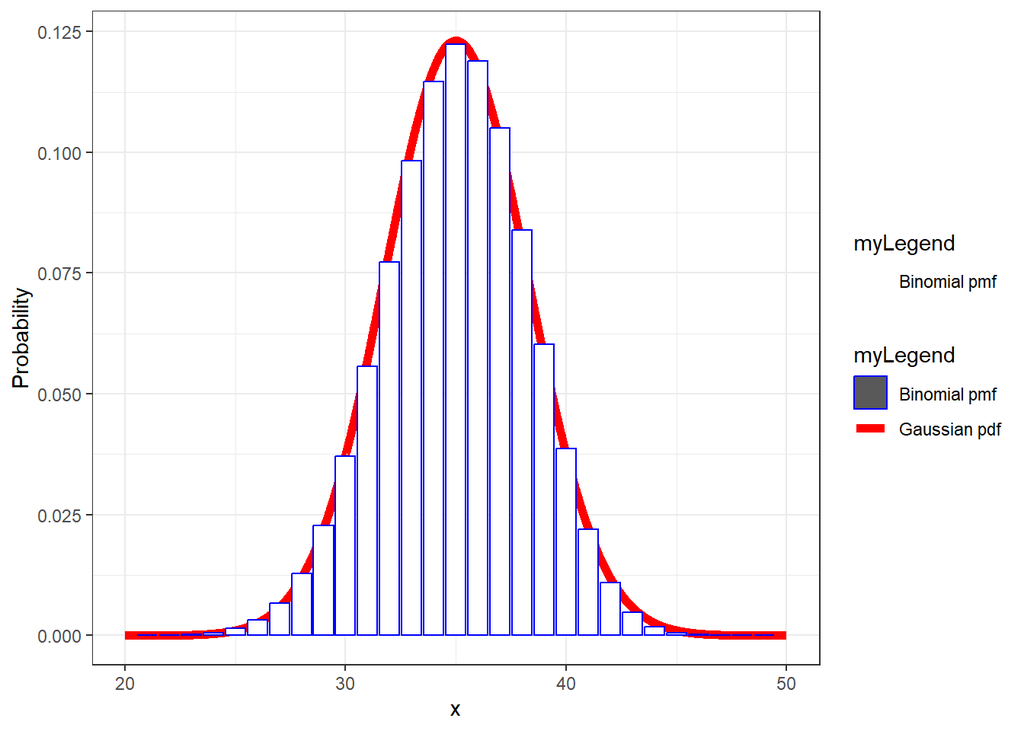

```r
colors <- c("Gaussian pdf"="red","Binomial pmf"="blue")
fill <- c("Gaussian pdf"="white","Binomial pmf"="white")

ggplot() + labs(x="x",y="Probability") + theme_bw() + geom_line(data=gaussian_df, aes(x,y=pdf,color="Gaussian pdf"), size=2) + geom_col(data=binom_df, aes(x=x,y=pmf,color="Binomial pmf", fill="Binomial pmf")) + scale_color_manual(name="myLegend", values=colors) + scale_fill_manual(name="myLegend",values=fill)+xlim(c(20,50))
```